# Leonardo.Porras.Ramírez.Lab1

Leonardo Porras

04-09-2026

```r
library(readxl)
library(knitr)
library(flextable)
```

```r
datos <- read_excel("BaseDatosServidores.xlsx")
```

```r
str(datos)
```

```
## tibble [100 × 12] (S3: tbl_df/tbl/data.frame)
##  $ ID_Nodo            : chr [1:100] "NODE-001" "NODE-002" "NODE-003" "NODE-004" ...
##  $ TipoEntorno        : chr [1:100] "BD" "BD" "WebAPI" "WebAPI" ...
##  $ ProveedorCloud     : chr [1:100] "AWS" "GCP" "Azure" "AWS" ...
##  $ NivelCarga         : chr [1:100] "Bajo" "Alto" "Medio" "Bajo" ...
##  $ EstadoServidor     : chr [1:100] "Óptimo" "Crítico" "Degradado" "Óptimo" ...
##  $ UsoCPU             : num [1:100] 25.3 89 66.9 31 61.9 98.7 46.5 17.6 24.9 89.1 ...
##  $ ContenedoresActivos: num [1:100] 3 5 12 8 4 11 10 18 9 3 ...
##  $ UsoRAM             : num [1:100] 51.3 42 21.3 23.8 43.1 23.8 26.6 15.1 27.5 41 ...
##  $ AnchoBanda         : num [1:100] 309 219 748 777 186 ...
##  $ Latencia           : num [1:100] 10.3 95 88.9 14.6 46.5 ...
##  $ TasaErrores        : num [1:100] 1.43 1.99 0.52 0.51 0.45 0.74 1.05 0.5 1.14 0.97 ...
##  $ TiempoUpTime       : num [1:100] 357 62 241 199 307 194 128 259 348 305 ...
```

# Pregunta 1:

# Tabla de distribución de frecuencias

# Variable: Estado del Servidor

```r
Freq <- as.vector(table(datos$EstadoServidor))

Porcentaje <- round(prop.table(Freq) * 100, 2)

Estado <- names(table(datos$EstadoServidor))

tabla_estado <- data.frame(
  Estado,
  Frecuencia_Absoluta = Freq,
  Porcentaje
)

colnames(tabla_estado) <- c(
  "Estado del Servidor",
  "Frecuencia Absoluta",
  "Porcentaje (%)"
)

tabla_estado
```

```
##   Estado del Servidor Frecuencia Absoluta Porcentaje (%)
## 1             Crítico                  19             19
## 2           Degradado                  29             29
## 3              Óptimo                  52             52
```

```r
tablaformal1 <- flextable(tabla_estado)

tablaformal1 <- set_caption(
  tablaformal1,
  "Cuadro 1: Distribución de servidores según Estado del Servidor, tercer cuatrimestre 2025"
)

tablaformal1 <- add_footer_lines(
  tablaformal1,
  "Fuente: BaseDatosServidores.xlsx"
)

tablaformal1
```

Cuadro 1: Distribución de servidores según Estado del Servidor, tercer cuatrimestre 2025

| Estado del Servidor | Frecuencia Absoluta | Porcentaje (%) |
| --- | --- | --- |
| Crítico | 19 | 19 |
| Degradado | 29 | 29 |
| Óptimo | 52 | 52 |

Fuente: BaseDatosServidores.xlsx

**Interpretación:** La tabla muestra la cantidad de servidores según su estado operativo. El estado con mayor frecuencia representa la condición más común dentro de la infraestructura.

# Pregunta 2:

# Nivel de Carga según Tipo de Entorno

```r
tabla_carga <- table(
  datos$TipoEntorno,
  datos$NivelCarga
)

tabla_carga
```

```
##
##          Alto Bajo Medio
##   Batch     6    4     8
##   BD       10    5    14
##   WebAPI   17   15    21
```

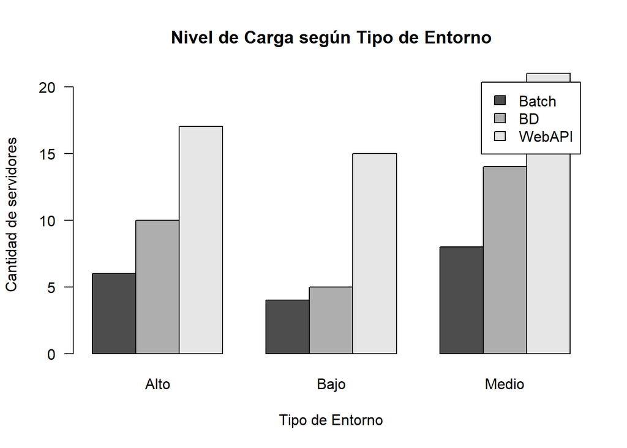

```r
barplot(
  tabla_carga,
  beside = TRUE,
  xlab = "Tipo de Entorno",
  ylab = "Cantidad de servidores",
  main = "Nivel de Carga según Tipo de Entorno",
  legend.text = TRUE,
  las = 1
)
```

**Interpretación:** El gráfico permite comparar los niveles de carga existentes en cada tipo de entorno de servidores

# Pregunta 3:

# Polígono de frecuencias absolutas

# Variable: UsoCPU

```r
clases_cpu <- seq(0, 100, 10)


datos$Clase_CPU <- cut(
  datos$UsoCPU,
  breaks = clases_cpu,
  right = FALSE,
  include.lowest = TRUE
)


Freq_CPU <- as.vector(table(datos$Clase_CPU))

Freq_CPU
```

```
##  [1]  0  7 13  4 13 14 15 10 10 14
```

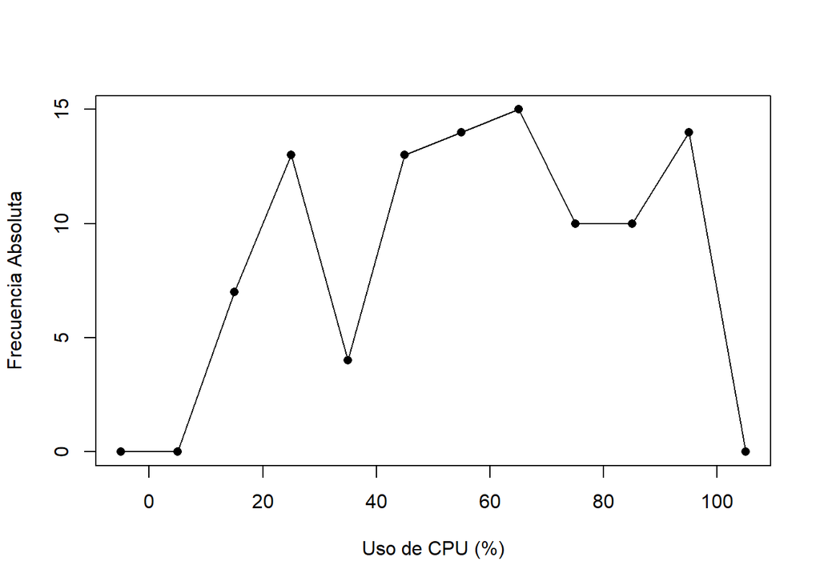

```r
Punto_medio <- seq(5, 95, 10)

poligono <- data.frame(
  Punto_medio = c(-5, Punto_medio, 105),
  Frecuencia = c(0, Freq_CPU, 0)
)

plot(
  poligono$Punto_medio,
  poligono$Frecuencia,
  type = "o",
  pch = 16,
  xlab = "Uso de CPU (%)",
  ylab = "Frecuencia Absoluta"
)
```

**Interpretación:** El polígono representa la distribución de los servidores según el porcentaje de uso que tenga el CPU.

# Pregunta 4:

# Mediana y desviación estándar

# Variable: Latencia para WebAPI

```r
latencia_webapi <- datos$Latencia[
  datos$TipoEntorno == "WebAPI"
]

mediana_latencia <- median(
  latencia_webapi,
  na.rm = TRUE
)

desviacion_latencia <- sd(
  latencia_webapi,
  na.rm = TRUE
)

mediana_latencia
```

```
## [1] 35.6
```

```r
desviacion_latencia
```

```
## [1] 40.0263
```

**Interpretación:** La mediana representa el valor central de la latencia de los servidores webAPI. La desviación estándar muestra la dispersión de los datos en relación al promedio.

# Pregunta 5:

# Cuartil 1 y Decil 7

# Variable: UsoRAM

```r
RAM <- sort(datos$UsoRAM)

n <- length(RAM)

pos_Q1 <- n * 0.25

pos_D7 <- n * 0.70

Q1 <- (RAM[pos_Q1] + RAM[pos_Q1 + 1]) / 2
D7 <- (RAM[pos_D7] + RAM[pos_D7 + 1]) / 2
Q1
```

```
## [1] 18.9
```

```r
D7
```

```
## [1] 34.3
```

**Interpretación:** El primer cuartil indica el valor donde se encuentra aproximadamente el 25% de los servidores.

El decil 7 indica el valor donde se encuentra aproximadamente el 70% de los servidores.

# Pregunta 6:

# Variable: TasaErrores según EstadoServidor

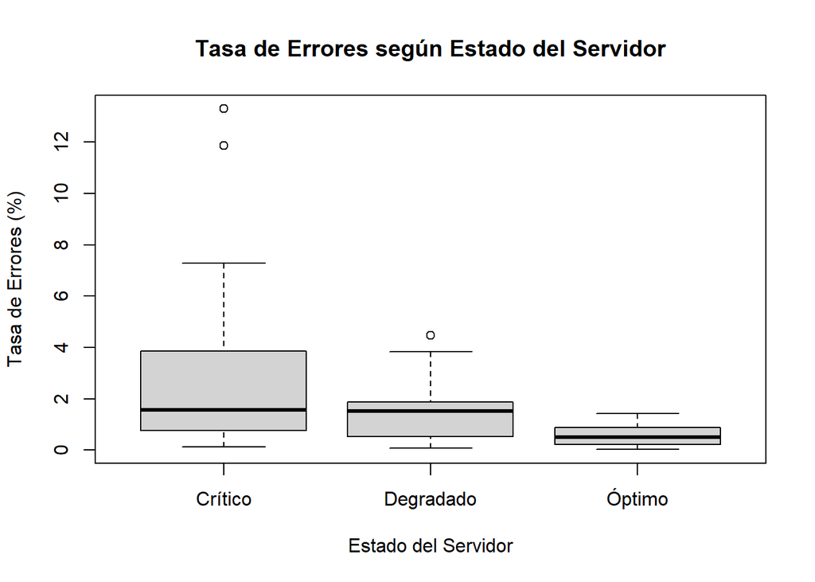

```r
boxplot(
  datos$TasaErrores ~ datos$EstadoServidor,
  xlab = "Estado del Servidor",
  ylab = "Tasa de Errores (%)",
  main = "Tasa de Errores según Estado del Servidor"
)
```

**Interpretación:** El diagrama compara la distribución de errores entre los diferentes estados de los servidores utilizados. Los estados con peor condición son los que más presentan errores.

# Pregunta 7:

# Variable: ContenedoresActivos

```r
cloud <- datos[
  datos$ProveedorCloud %in% c("AWS", "Azure"),
]

resultado_cv <- aggregate(
  ContenedoresActivos ~ ProveedorCloud,
  data = cloud,
  FUN = function(x)
    c(
      Media = mean(x),
      Desviacion = sd(x),
      CV = sd(x) / mean(x) * 100
    )
)

resultado_cv
```

```
##   ProveedorCloud ContenedoresActivos.Media ContenedoresActivos.Desviacion
## 1            AWS                 11.204082                       6.314598
## 2          Azure                  9.741935                       6.617994
##   ContenedoresActivos.CV
## 1              56.359801
## 2              67.933055
```

**Interpretación:** El proveedor que tenga el mayor coeficienre de variación presenta mayor variabilidad relativa en la cantidad de contenedores activos.